# Mortality Modeling

# Modeling ———————————————————————

## Model 1: model_no_hospital

```r
if (params$refit_model_no_hospital) {
  tic()
  model_no_hospital <- glm(
    formula = death_due_to_covid  ~ decades_old + gender + race +
              adj_perc_bach_quar + adj_perc_insured_quar +
              adj_pop_density + adj_med_income +
              adj_time_days,
    family = binomial,
    data = usable_cases
    )
  toc()
  #
  # 3.316 sec elapsed
  # updated and saved 2022-06-08
    save(model_no_hospital, file = here("analysis/testing-mortality-regression-results", "model_no_hospital.Rdata"))
  } else {
    load(file = here("analysis/testing-mortality-regression-results", "model_no_hospital.Rdata"))
}

summary(model_no_hospital)
```

```
##
## Call:
## glm(formula = death_due_to_covid ~ decades_old + gender + race +
##     adj_perc_bach_quar + adj_perc_insured_quar + adj_pop_density +
##     adj_med_income + adj_time_days, family = binomial, data = usable_cases)
##
## Deviance Residuals:
##     Min       1Q   Median       3Q      Max
## -2.0186  -0.1009  -0.0455  -0.0221   4.1759
##
## Coefficients:
##                           Estimate Std. Error z value Pr(>|z|)
## (Intercept)             -1.026e+01  1.385e-01 -74.062  < 2e-16 ***
## decades_old              9.894e-01  1.416e-02  69.894  < 2e-16 ***
## gendermale               7.167e-01  4.429e-02  16.182  < 2e-16 ***
## raceasian                3.184e-01  6.676e-02   4.769 1.85e-06 ***
## raceblack               -3.152e-01  2.239e-01  -1.408  0.15927
## racehispanic            -3.593e-01  7.853e-02  -4.576 4.74e-06 ***
## racenative              -1.349e-01  5.664e-01  -0.238  0.81179
## raceislander             1.593e-01  2.793e-01   0.570  0.56843
## raceunknown             -7.629e-01  5.275e-02 -14.461  < 2e-16 ***
## adj_perc_bach_quarQ2    -2.213e-01  7.182e-02  -3.081  0.00206 **
## adj_perc_bach_quarQ3    -2.821e-01  1.015e-01  -2.780  0.00543 **
## adj_perc_bach_quarQ4    -5.882e-01  1.498e-01  -3.925 8.66e-05 ***
## adj_perc_insured_quarQ2 -1.233e-01  6.114e-02  -2.017  0.04370 *
## adj_perc_insured_quarQ3  4.582e-04  9.686e-02   0.005  0.99623
## adj_perc_insured_quarQ4 -5.330e-01  1.241e-01  -4.295 1.75e-05 ***
## adj_pop_density         -2.909e-02  3.437e-02  -0.846  0.39737
## adj_med_income          -1.278e-01  5.668e-02  -2.254  0.02418 *
## adj_time_days           -6.326e-01  1.744e-02 -36.280  < 2e-16 ***
## ---
## Signif. codes:  0 '***' 0.001 '**' 0.01 '*' 0.05 '.' 0.1 ' ' 1
##
## (Dispersion parameter for binomial family taken to be 1)
##
##     Null deviance: 28656  on 211250  degrees of freedom
## Residual deviance: 18016  on 211233  degrees of freedom
## AIC: 18052
##
## Number of Fisher Scoring iterations: 9
```

## Model 2: model_covid_beds ; All predictors (adj_covid_icu_beds = scaled # occupied icu beds by covid pts)

```r
if (params$refit_model_covid_beds) {
  tic()
  model_covid_beds <- glm(
    formula = death_due_to_covid  ~ decades_old + gender + race +
              adj_perc_bach_quar + adj_perc_insured_quar +
              adj_pop_density + adj_med_income +
              adj_time_days + adj_covid_icu_beds, # hospital bed predictor
    family = binomial,
    data = usable_cases
    )
  toc()
  #
  # 3.928 sec elapsed
  # updated and saved 2022-06-08
    save(model_covid_beds, file = here("analysis/testing-mortality-regression-results", "model_covid_beds.Rdata"))
  } else {
    load(file = here("analysis/testing-mortality-regression-results", "model_covid_beds.Rdata"))
}
```

```r
compare_bic <- BIC(model_no_hospital, model_covid_beds)
row.names(compare_bic) <- c("model_no_hospital", "model_covid_beds")
compare_bic %>% kbl(caption = "Model Comparison using BIC") %>%
 kable_classic(full_width = F, html_font = "Cambria")
```

Model Comparison using BIC

|  | df | BIC |
| --- | --- | --- |
| model_no_hospital | 18 | 18237.10 |
| model_covid_beds | 19 | 17791.32 |

## Model 3A: model_avail_beds ; All predictors (adj_perc_avail_beds = **percentage** of avail icu beds)

```r
if (params$refit_model_avail_beds) {
  tic()
  model_avail_beds <- glm(
    formula = death_due_to_covid  ~ decades_old + gender + race +
              adj_perc_bach_quar + adj_perc_insured_quar +
              adj_pop_density + adj_med_income +
              adj_time_days + adj_perc_avail_beds, # hospital bed predictor
    family = binomial,
    data = usable_cases
    )
  toc()
  #
  # 2.858 sec elapsed
  # updated and saved 2022-06-08
    save(model_avail_beds, file = here("analysis/testing-mortality-regression-results", "model_avail_beds.Rdata"))
  } else {
    load(file = here("analysis/testing-mortality-regression-results", "model_avail_beds.Rdata"))
}
```

## Model 3B: model_avail_beds_not_percentage ; All predictors (adj_avail_icu_beds = **number** of avail icu beds)

```r
if (params$refit_model_avail_beds_not_percentage) {
  tic()
  model_avail_beds_not_percentage <- glm(
    formula = death_due_to_covid  ~ decades_old + gender + race +
              adj_perc_bach_quar + adj_perc_insured_quar +
              adj_pop_density + adj_med_income +
              adj_time_days + adj_avail_icu_beds, # hospital bed predictor
    family = binomial,
    data = usable_cases
    )
  toc()
  #
  # 3.66 sec elapsed
  # updated and saved 2022-06-08
    save(model_avail_beds_not_percentage, file = here("analysis/testing-mortality-regression-results", "model_avail_beds_not_percentage.Rdata"))
  } else {
    load(file = here("analysis/testing-mortality-regression-results", "model_avail_beds_not_percentage.Rdata"))
}
```

```r
compare_bic <- BIC(model_covid_beds, model_avail_beds, model_avail_beds_not_percentage)
row.names(compare_bic) <- c("model_covid_beds", "model_avail_beds", "model_avail_beds_not_percentage")
compare_bic %>% kbl(caption = "Model Comparison using BIC") %>%
 kable_classic(full_width = F, html_font = "Cambria")
```

Model Comparison using BIC

|  | df | BIC |
| --- | --- | --- |
| model_covid_beds | 19 | 17791.32 |
| model_avail_beds | 19 | 17812.38 |
| model_avail_beds_not_percentage | 19 | 18027.42 |

## Model 4: model_inter_time_bed

```r
if (params$refit_model_inter_time_bed) {
  tic()
  model_inter_time_bed <- glm(
    formula = death_due_to_covid  ~ decades_old + gender + race +
              adj_perc_bach_quar + adj_perc_insured_quar +
              adj_pop_density + adj_med_income +
              adj_time_days +  adj_covid_icu_beds + adj_time_days:adj_covid_icu_beds,
    family = binomial,
    data = usable_cases
    )
  toc()
  #
  # 3.041 sec elapsed
  # updated and saved 2022-06-08
    save(model_inter_time_bed, file = here("analysis/testing-mortality-regression-results", "model_inter_time_bed.Rdata"))
  } else {
    load(file = here("analysis/testing-mortality-regression-results", "model_inter_time_bed.Rdata"))
}
```

```r
compare_bic <- BIC(model_covid_beds, model_inter_time_bed)
row.names(compare_bic) <- c("model_covid_beds", "model_inter_time_bed")
compare_bic %>% kbl(caption = "Model Comparison using BIC") %>%
 kable_classic(full_width = F, html_font = "Cambria")
```

Model Comparison using BIC

|  | df | BIC |
| --- | --- | --- |
| model_covid_beds | 19 | 17791.32 |
| model_inter_time_bed | 20 | 17693.74 |

## Model 5: model_random_zip ; All predictors (adj_covid_icu_beds + interaction), random intercept

```r
if (params$refit_model_random_zip) {
  tic()
  model_random_zip <- glmer(
    formula = death_due_to_covid  ~ decades_old + gender + race +
              adj_perc_bach_quar + adj_perc_insured_quar +
              adj_pop_density + adj_med_income +
              adj_time_days +  adj_covid_icu_beds + adj_time_days:adj_covid_icu_beds +
      (1|zip), # random intercept
    family = binomial,
    data = usable_cases,
    control = glmerControl(optimizer ="bobyqa", optCtrl = list(maxfun = 2e6))
    )
    toc()
  #
  # 2055.78 sec elapsed
  # updated and saved 2022-06-08
    save(model_random_zip, file = here("analysis/testing-mortality-regression-results", "model_random_zip.Rdata"))
  } else {
    load(file = here("analysis/testing-mortality-regression-results", "model_random_zip.Rdata"))
}
```

```r
compare_bic <- BIC(model_inter_time_bed, model_random_zip)
row.names(compare_bic) <- c("model_inter_time_bed", "model_random_zip")
compare_bic %>% kbl(caption = "Model Comparison using BIC") %>%
 kable_classic(full_width = F, html_font = "Cambria")
```

Model Comparison using BIC

|  | df | BIC |
| --- | --- | --- |
| model_inter_time_bed | 20 | 17693.74 |
| model_random_zip | 21 | 17684.43 |

- Space is a confounder in which people within close spacial proximity will have similar risk of dying from COVID-19. Each individual belongs to a certain zip code, and individuals within each zip code are correlated. When we have clustered data with correlations within the clusters, we can control for this by adding a random intercept for cluster ID, or zip code in this case. From the model comparison, adding a random intercept for zip code improved the model.

```r
compare_bic <- BIC(model_no_hospital,
                   model_covid_beds,
                   model_avail_beds,
                   model_avail_beds_not_percentage,
                   model_inter_time_bed,
                   model_random_zip)
row.names(compare_bic) <- c("model_no_hospital",
                            "model_covid_beds",
                            "model_avail_beds",
                            "model_avail_beds_not_percentage",
                            "model_inter_time_bed",
                            "model_random_zip")
compare_bic %>% kbl(caption = "Mortality Model Comparison using BIC") %>%
 kable_classic(full_width = F, html_font = "Cambria")
```

Mortality Model Comparison using BIC

|  | df | BIC |
| --- | --- | --- |
| model_no_hospital | 18 | 18237.10 |
| model_covid_beds | 19 | 17791.32 |
| model_avail_beds | 19 | 17812.38 |
| model_avail_beds_not_percentage | 19 | 18027.42 |
| model_inter_time_bed | 20 | 17693.74 |
| model_random_zip | 21 | 17684.43 |

```r
# rsq(model_random_zip,adj=TRUE,type=c('v','kl','sse','lr','n'))

se <- sqrt(diag(vcov(model_random_zip)))

tab <- cbind(Est = fixef(model_random_zip),
             LL = fixef(model_random_zip) - 1.96 * se,
             UL = fixef(model_random_zip) + 1.96 *se
             )

print(exp(tab))
```

```
##                                           Est           LL           UL
## (Intercept)                      5.422402e-05 0.0000389062 7.557265e-05
## decades_old                      2.731917e+00 2.6547475795 2.811330e+00
## gendermale                       2.083390e+00 1.9078341896 2.275101e+00
## raceasian                        1.379111e+00 1.2029694074 1.581043e+00
## raceblack                        7.606138e-01 0.4890025503 1.183089e+00
## racehispanic                     6.349033e-01 0.5428674116 7.425426e-01
## racenative                       8.848385e-01 0.2918300854 2.682860e+00
## raceislander                     1.253460e+00 0.7202226376 2.181497e+00
## raceunknown                      4.393656e-01 0.3953035215 4.883390e-01
## adj_perc_bach_quarQ2             8.158519e-01 0.6448587006 1.032186e+00
## adj_perc_bach_quarQ3             7.251077e-01 0.5286311947 9.946086e-01
## adj_perc_bach_quarQ4             5.388105e-01 0.3552688798 8.171749e-01
## adj_perc_insured_quarQ2          8.673320e-01 0.7049030304 1.067189e+00
## adj_perc_insured_quarQ3          9.650955e-01 0.7168280626 1.299348e+00
## adj_perc_insured_quarQ4          6.062304e-01 0.4231984484 8.684231e-01
## adj_pop_density                  9.627082e-01 0.8582633373 1.079863e+00
## adj_med_income                   8.725702e-01 0.7460060581 1.020607e+00
## adj_time_days                    7.622642e-01 0.7221125240 8.046484e-01
## adj_covid_icu_beds               7.862577e-01 0.7486088179 8.258001e-01
## adj_time_days:adj_covid_icu_beds 7.586590e-01 0.7199855340 7.994099e-01
```

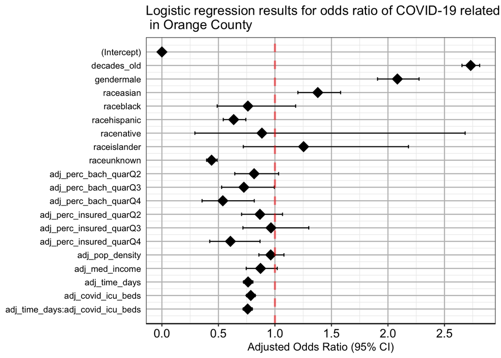

```r
index <- c(1:20)
tab_2 <- data.frame(exp(tab))

plot1 <- ggplot(tab_2, aes(y = index, x = tab_2[, 1])) +
  geom_point(shape = 18, size = 5) +
  geom_errorbarh(aes(xmin = LL, xmax = UL), height = 0.25) +
  geom_vline(xintercept = 1, color = "red", linetype = "dashed", cex = 1, alpha = 0.5) +
  scale_y_continuous(name = "", breaks=1:20, labels = row.names(tab_2), trans = "reverse") +
  scale_x_continuous(breaks = seq(0, 2.5, by = 0.5)) +
  xlab("Adjusted Odds Ratio (95% CI)") +
  ylab(" ") +
  theme_bw() +
  theme(
    axis.title.y = element_blank(),
    axis.text.x=element_text(size = 12, colour="black"),
    axis.text.y=element_text(colour="black", hjust = 1),
    axis.ticks.y = element_blank(),
    axis.line.x = element_line(color = "black"),
    panel.grid.major = element_line(colour = "gray"),
    panel.background = element_blank(),
    plot.title = element_text(hjust=0)
  ) +
  ggtitle("Logistic regression results for odds ratio of COVID-19 related mortality given SARS-CoV-2 positive \n in Orange County")

plot1
```

### Interpretations

- We decided to go with a multivariate model since we are able to control for different predictors while simultaneously interpreting the effect of a single predictor. The covariates in our final model that were significant at the 5% significance level were: age, gender, education, covid icu beds, race(some levels), health insurance (only highest level was significant). The interaction term between time and the covid icu beds predictor was also significiant.

#### Intercept ———————–

- Model intercept represents odds of death for a white female diagnosed with SARS-CoV-2 in the 0 to 4 age group in a ZIP code in the first quartile of college degree and insured with the average population density and average number of ICU beds filled with COVID patients in Orange County. The odds of this individual dying is estimated to be 0 (0,0).

#### Age ———————–

- For a 10 year increase in age, we observed an associated 2.7-fold increase in the odds of dying from COVID-19.

#### Gender ———————–

- The odds of death from COVID-19 for a male is expected to be 2 times that of a female.

#### Race ———————–

- Compared to non-hispanic whites, Asians had a 38% higher odds of dying from COVID-19.
- Compared to non-hispanic whites, Hispanics had a 37% lower odds of dying from COVID-19.
- Compared to non-hispanic whites, those with an unknown race had a 56% lower odds of dying from COVID-19.

#### Education ———————–

*** NOTE: Quartile associated with scaled percentage of adults with a bachelor’s degree within a particular ZIP code. Depending on the distribution of the percentages, you will fall within the lower 25%, between 25% and 50%, between 50% and 75%, or the top 25% of the data. For example, if a particular individual’s value is Q1, then that would would mean they live in a ZIP code where the percentage of adults with a bachelor’s degree is low relative to other ZIP codes.

- The odds of death from COVID-19 for an individual in a ZIP code in the **second** quartile of college degree is expected to be **0.82** times that of a similar individual in a ZIP code in the first quartile of college degree.
  - The odds of death from COVID-19 for an individual in a ZIP code in the **third** quartile of college degree is expected to be **0.73** times that of a similar individual in a ZIP code in the first quartile of college degree.
  - The odds of death from COVID-19 for an individual in a ZIP code in the **fourth** quartile of college degree is expected to be **0.54** times that of a similar individual in a ZIP code in the first quartile of college degree.
- Living in ZIP codes with the highest education levels was also predictive of mortality outcomes. The odds of dying from COVID-19 for an individual in a ZIP code in the third or fourth quartile of college degree was 27% and 46% lower (respectively) than that of a similar individual in a ZIP code in the first quartile of college degree.

#### Health Insurance ———————–

- The odds of death from COVID-19 for an individual in a ZIP code in the **second** quartile of health insurance is expected to be **0.87** times that of a similar individual in a ZIP code in the first quartile of health insurance.
  - The odds of death from COVID-19 for an individual in a ZIP code in the **third** quartile of health insurance is expected to be **0.97** times that of a similar individual in a ZIP code in the first quartile of health insurance.
  - The odds of death from COVID-19 for an individual in a ZIP code in the **fourth** quartile of health insurance is expected to be **0.61** times that of a similar individual in a ZIP code in the first quartile of health insurance.
- Living in a ZIP code with the highest level of health insurance was predictive of mortality outcomes. The odds of dying from COVID-19 for an individual in a ZIP code in the fourth quartile was 39% lower than that of a similar individual in a ZIP code in the first quartile of health insurance.

#### Hospital Bed Predictor ———————–

- The odds of dying from COVID-19 for an individual who tested positive on a day with a high number of occupied ICU beds was 21% lower than that of a similar individual who tested positive on a day with a lower number of occupied ICU beds

#### Interaction Term (adj_time_days:adj_covid_icu_beds) —————————

**Does the effect of the number of occupied ICU beds in OC on the risk of dying from COVID-19 depend on time?**

- The effect of the number of occupied ICU beds in OC on odds of dying from COVID-19 depends on the time of which the individual tested positive (relative to the first testing date).
- The added effect of an increase in time_days by 1 for a 1 unit increase in covid_icu_beds on the odds of dying from COVID-19 is a 24% lower odds.